# Donnermeyer_Homework_8

Sam Donnermeyer

11/19/2020

## STAT 451: Hand In Homework #8

### Sam Donnermeyer

#### **(a)** Create side-by-side boxplots of the net weights with proper labels and describe what you find, focusing on the comparison of the two samples.

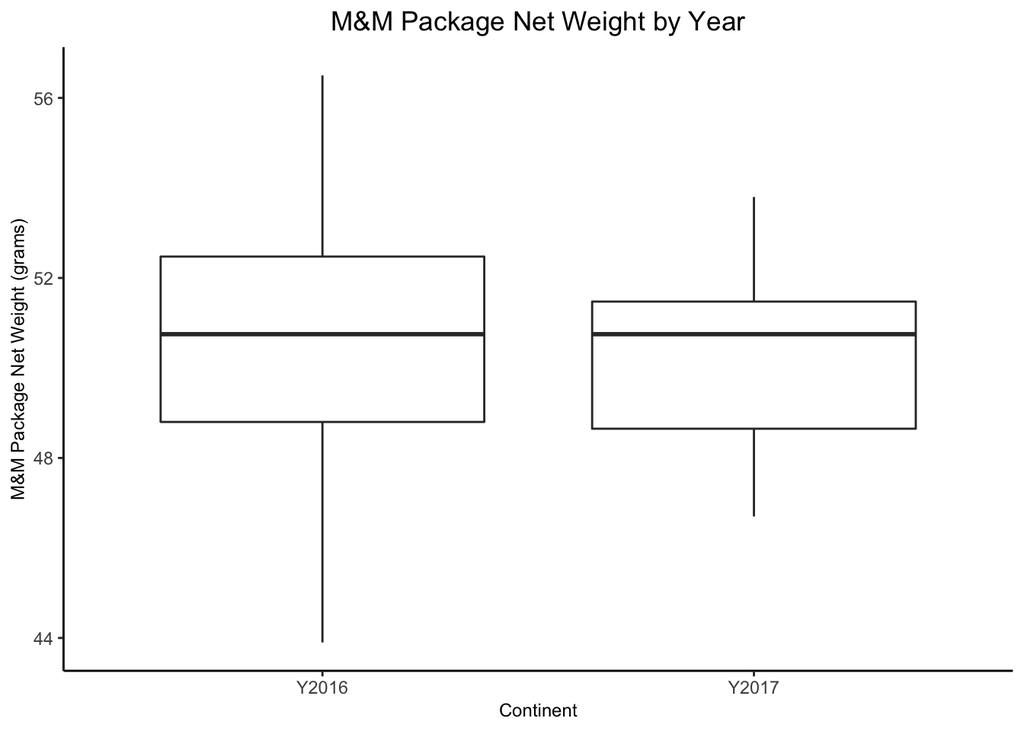

```r
# Create boxplots of the net weights - separated by year
boxplot = ggplot(data_df, aes(Year, NetWt)) +
  geom_boxplot(outlier.colour="black", outlier.shape=16,
             outlier.size=2, notch=FALSE) +
  # Add x label
  xlab("Continent") +
  # Add y label
  ylab("M&M Package Net Weight (grams)") +
  # Add title to the chart
  ggtitle("M&M Package Net Weight by Year") +
  # Themes
  scale_colour_viridis_d() +
  # Theme
  theme(
    # hide panel borders and remove grid lines
    panel.background = element_rect(fill = "white"),
    panel.border = element_blank(),
    panel.grid.major = element_blank(),
    panel.grid.minor = element_blank(),
    # change axis titles
    axis.line = element_line(color = "black"),
    axis.title = element_text(size=9),
    # Change the title orientation
    plot.title = element_text(hjust = 0.5)
  )

boxplot
```

The preceding box-plots reveal interesting aspects of the distribution of M&M’s net weight of packages between the years 2016 & 2017. - Both 2016 & 2017 have very similar medians (~ 51 grams), however, their spread is very different. 2017 M&M packages have much less variability, while 2016 has a much larger IQR and overall spread.

#### **(b)** Do the assumptions of t procedures appear satisfied?

Assumptions: - Randomization Condition: The data are from a simple random sample from the population. - The sample is assumed to be a simple random sample from shipments of M&M’s the store received in the respective years. - 10% Condition: The sample is no more than 10% of the population. - Yes, 48 bags is no more than 10% of the population. - Normality: The data come from a normal population. - Since n for each year is 15 $\le$ n $\le$ 40, it is assumed that the population distribution is unimodal and roughly symmetric.

#### **(c)** Report the group means, standard deviations and sample sizes in a table.

```r
# Create Summaries of the groups
summary <- function(x){
  c(mean=mean(x), sd=sd(x), length=length(x))
}

summaryBy(NetWt~Year, data = data_df, FUN = summary)
```

```
## # A tibble: 2 x 4
##   Year  NetWt.mean NetWt.sd NetWt.length
##   <chr>      <dbl>    <dbl>        <dbl>
## 1 Y2016       50.6     3.12           30
## 2 Y2017       50.3     2.11           18
```

#### **(d)** Report the 99% confidence interval for the difference in means.

```r
## Create a 99% confidence interval for the difference in means ##
# separate data by year
data_2016 = data_df[which(data_df$Year == "Y2016"),]
data_2017 = data_df[which(data_df$Year == "Y2017"),]

# Confidence Interval for the difference of two means
t_test = t.test(data_2016$NetWt, data_2017$NetWt, data = data_df, conf.level = .99)
t_test
```

```
##
##  Welch Two Sample t-test
##
## data:  data_2016$NetWt and data_2017$NetWt
## t = 0.38485, df = 45.189, p-value = 0.7022
## alternative hypothesis: true difference in means is not equal to 0
## 99 percent confidence interval:
##  -1.742977  2.325199
## sample estimates:
## mean of x mean of y
##  50.59667  50.30556
```

We are 99% confident that the mean effect of the 2016 sample from the 2017 sample of net weight of M&M packages is in the interval (-1.743, 2.325).

#### **(e)** Report the P-value for a two-sided test of the hypothesis that the two population means are equal

The p-value for the two-sided test of the hypothesis that the population means between the net weight of M&M packages in 2016 and 2017 is p-value = 0.702. With a p-value of 0.702, there is no evidence in favor that the mean net weight of M&M packages in 2016 and 2017 are different.